# Reproducible Research: Peer Assessment 1

## Loading and preprocessing the data

The chunk below sets the working directory, reads the data into an object called “activ” and then creates a data frame ‘totsteps’ containing the sum total of all steps taken per day, dropping missing cases.

```r
setwd("~/Dropbox/In process/MyRWork")
activ <- read.csv("activity.csv", header = TRUE)
# Need to express per day
library(dplyr)
byday <- group_by(activ, date)
totsteps <- summarize(byday,tot_steps=sum(steps, na.rm=TRUE))
```

## What is mean total number of steps taken per day?

In this section, we first create a histogram of the number of steps per day, and then go on to compute and report the mean and median number of steps per day.

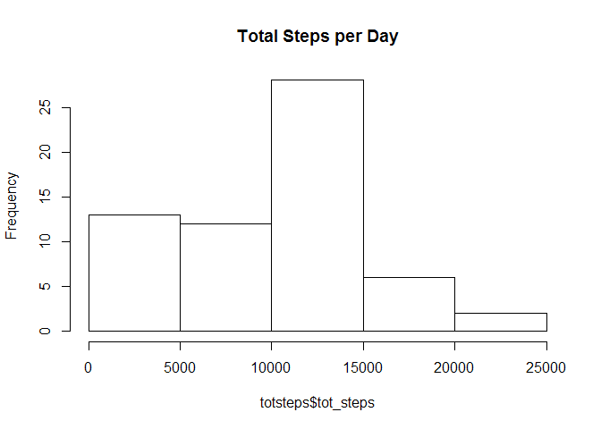

```r
hist(totsteps$tot_steps, main="Total Steps per Day")
```

```r
mean_tot <- summarize(totsteps, m = mean(tot_steps))
med_tot <- median(totsteps$tot_steps)
```

The mean number of steps per day is 9354.2295082 and the median is 10395

## What is the average daily activity pattern?

To identify the daily pattern, it is first necessary to summarize the mean number of steps per 5-minute interval. I did this again using dplyr and omitting missing data. Once the data were prepared, it’s a small matter to create a time series plot. Note that this graph uses a data frame called ‘mean_step’ which contains the mean number of steps per 5-minute interval for the 288 intervals.

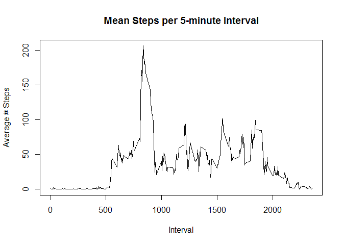

```r
by_int <- group_by(activ, interval)
mean_step <- summarize(by_int, mean_steps=mean(steps, na.rm=TRUE))

plot(mean_step$interval, mean_step$mean_steps, type="l",
     main="Mean Steps per 5-minute Interval", xlab="Interval",
     ylab="Average # Steps")
```

```r
#Which 5-minute interval, on average across all the days in the dataset, contains the maximum number of steps?
i <-which.max(mean_step$mean_steps)
maxint <- mean_step$interval[i]
```

From the plot we can see that 835 is the most active of the day, on average.

## Imputing missing values and re-do first part of the analysis

As specified in the assignment, first I computed the number of missing values in the dataset, and then proceed to impute values for the missing cases. For this assignment, I decided to replace missing values with the mean number of steps for the corresponding 5-minute interval.

After a couple of unsuccessful approaches, I consulted the class discussion, and followed the recommendation of Community TA Sebastián Jojoa Cruz. Thanks Sebastián!

Note one odd calculation in this code: the vector ‘ints’ is meant to point to the means within the data frame of intervals; hence I wanted ints to map an interval number to a *row numbers* in that data frame. Since the intervals are numbered 5, 10, 15 etc. we can map an interval number to a row number muliplying the interval number by .2 and adding 1.

```r
#Calculate and report the total number of missing values in the dataset (i.e. the total number of rows with NAs)
nas <- sum(is.na(activ$steps))
activ$stepsnm <- activ$steps
ind <- is.na(activ$stepsnm) # vector of rows with missing observations
ints <- 1+.2* activ$interval[ind] # identify row of intervals for each missing obs
activ$stepsnm[ind] <- mean_step$mean_steps[ints] #swap NA with mean for interval
```

In the original dataset, there were 2304 missing cases for the Number of Steps variable.

Now, having replaced the missing observations with the means for each interval, we repeat the first portion of the analysis.

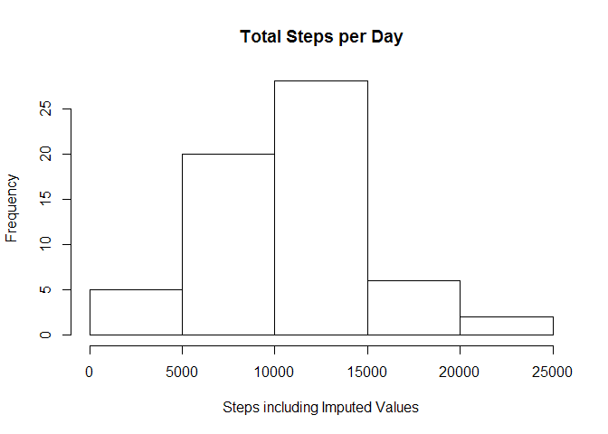

```r
byday2 <- group_by(activ, date)
totsteps2 <- summarize(byday2,tot_steps2=sum(stepsnm, na.rm=TRUE))
hist(totsteps2$tot_steps2, main="Total Steps per Day",
        xlab="Steps including Imputed Values")
```

```r
mean_tot2 <- summarize(totsteps2, m2 = mean(tot_steps2))
med2 <-median(totsteps2$tot_steps2)
```

Here we see that the histogram is slightly more symmetric and mound-shaped than the original histogram.

The new mean is 1.028214310^{4} compared with the earlier value of 9354.2295082.

The new median is 1.039510^{4}, compared with the earlier value of 10395– no change at all.

## Are there differences in activity patterns between weekdays and weekends?

For this final portion of the analysis, it was necessary to create a factor variable with two levels: “weekend” and “weekday”, and then recreate the daily activity pattern graphs in two panels, separating weekends and weekdays.

I chose to use the lattice package to create the plot.

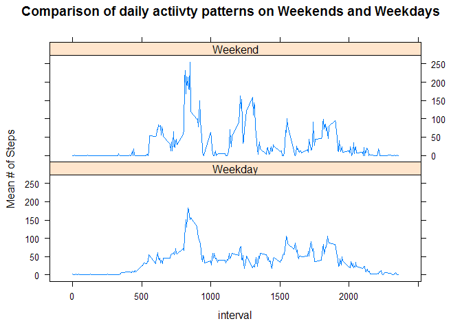

```r
wend <- c("Saturday", "Sunday")

activ <- activ %>%
        mutate(day = ifelse(weekdays(as.Date(activ$date)) %in% wend,
                 "Weekend", "Weekday"))

activ$day <- as.factor(activ$day)


#Make a panel plot containing a time series plot (i.e. type = "l") of the 5-minute #interval (x-axis) and the average number of steps taken, averaged across all weekday # days or weekend days (y-axis).
by_int2 <- group_by(activ, day, interval)
mean_step2 <- summarize(by_int2, msteps =mean(stepsnm, na.rm=TRUE))

library(lattice)
xyplot(msteps ~ interval | day, data=mean_step2, type = "l",
       main="Comparison of daily actiivty patterns on Weekends and Weekdays",
       ylab="Mean # of Steps", layout = c (1,2))
```

We note the general similarity in shape, with one particular difference. The weekend pattern has an addition spike roughly between intervals 1100-1300 that does not appear in such a pronounced way on weekdays.